# Logistic Regression: Effect Modification

Lecture 3A

PUBHBIO 6250

## Effect Modification (Interaction)

- Logistic regression model

$$g(x_1,x_2)=\beta_0+\beta_1x_1+\beta_2x_2+\beta_3x_1x_2$$

- $x_1,x_2$ are continuous or dichotomous
- $\beta_3$ = interaction effect
- $x_2$ is an effect modifier of $x_1$ if effect of $x_1$ on logit changes with $x_2$.
- For a categorical predictor with more than 2 levels, we need to include interaction terms for each level.

## Interaction with Two Binary Predictors

- Based on the WCGS data, the presence of corneal arcus senilis (arcus) is associated with an increased odds of CHD.
  - $\widehat{OR} = 1.634$
- **Question**:
  - Is arcus as strongly associated with CHD in older as it is in younger people?
  - Does the effect of arcus on CHD depend on age group?
- **Variables**: $\texttt{arcus} =\begin{cases} 1 & \text{has corneal arcus }\\ 0 & \text{otherwise} \end{cases}$ $\quad$ $\texttt{age50} = \begin{cases} 1 & \text{if age } >50\\ 0 & \text{otherwise} \end{cases}$
- **Model:** $g(\texttt{arcus}, \texttt{age50}) = \beta_0 + \beta_1 \texttt{arcus} + \beta_2 \texttt{age50} + \textcolor{#BB0000}{\beta_3 \texttt{arcus} \times \texttt{age50}}$

## Effect of arcus Depends on Age Group

$$g(\texttt{arcus}, \texttt{age50}) = \beta_0 + \beta_1 \texttt{arcus} + \beta_2 \texttt{age50} + \textcolor{#BB0000}{\beta_3 \texttt{arcus} \times \texttt{age50}}$$

For **younger** people (age $<$ 50) $\rightarrow \texttt{age50} = 0$

$g(\texttt{arcus}=0, \texttt{age50}=0) = \beta_0$

$g(\texttt{arcus}=1, \texttt{age50}=0) = \beta_0 + \beta_1$

$$OR = \frac{\exp(\beta_0 + \beta_1)}{\exp(\beta_0)} = \exp(\beta_1)$$

For **older** people (age $>$ 50) $\rightarrow \texttt{age50} = 1$

$g(\texttt{arcus}=0, \texttt{age50}=1) = \beta_0 + \beta_2$

$g(\texttt{arcus}=1, \texttt{age50}=1) = \beta_0 + \beta_1 + \beta_2 + \beta_3$

## Estimates from Software

$$g(\texttt{arcus}, \texttt{age50}) = \beta_0 + \beta_1 \texttt{arcus} + \beta_2 \texttt{age50} + \beta_3 \texttt{arcus} \times \texttt{age50}$$

- Software output gives:

  $\hat{\beta}_0=-2.8862$, $\hat{\beta}_1=0.6980$, $\hat{\beta}_2=1.0351$, and $\hat{\beta}_3=-0.8034$
- Estimated odds ratio by age group (for effect of `arcus`)
  - For `age50` = 0: $\exp(\hat{\beta}_1) = \exp(0.6980)=2.0097$
  - For `age50` = 1: $\exp(\hat{\beta}_1+\hat{\beta}_3) = \exp(0.6980 - 0.8034)=0.89996$
- **Interpretations**
  - Among subjects aged 50 years or younger, the estimated odds of CHD for people with arcus are **2** times those for people without arcus.
  - Among subjects older than 50 years, the estimated odds of CHD for people with arcus are **0.9** times those for people without arcus.

## Interaction with Binary and Continuous Predictors

- We just modeled the log-odds of CHD and were interested in the OR comparing those with arcus to those without arcus when categorical age is an effect modifier.
- We could instead treat age as continuous.
- Logistic regression model in which age is treated as a continuous variable:

$$g(\texttt{arcus},\texttt{age}) = \beta_0+\beta_1\texttt{arcus}+\beta_2\texttt{age}+ \textcolor{#9400D1}{\beta_3\texttt{age} \times \texttt{arcus}}$$

## Effect of arcus Depends on Age

$$g(\texttt{arcus},\texttt{age}) = \beta_0+\beta_1\texttt{arcus}+\beta_2\texttt{age}+ \textcolor{#9400D1}{\beta_3\texttt{age} \times \texttt{arcus}}$$

- OR comparing those with arcus to those without arcus

$$\begin{aligned}
g(\texttt{arcus}=0,\texttt{age}) &= \beta_0 + \beta_2 \texttt{age} \\
g(\texttt{arcus}=1,\texttt{age}) &= \beta_0 + \beta_1 + \beta_2 \texttt{age} + \textcolor{#9400D1}{\beta_3} \texttt{age} \\
&= (\beta_0 + \beta_1) + (\beta_2 + \textcolor{#9400D1}{\beta_3}) \texttt{age}
\end{aligned}$$

$$OR = \frac{\exp\left( \beta_0 + \beta_1 +\beta_2 \texttt{age} + \beta_3 \texttt{age} \right)}{\exp\left( \beta_0 +\beta_2 \texttt{age} \right)} = \exp \left(\beta_1 + \textcolor{#9400D1}{\beta_3} \texttt{age} \right)$$

## Estimates from Software

$$g(\texttt{arcus},\texttt{age}) = \beta_0+\beta_1\texttt{arcus}+\beta_2\texttt{age}+ \textcolor{#9400D1}{\beta_3\texttt{age} \times \texttt{arcus}}$$

- Software output gives:

  $\hat{\beta}_0=-6.8142$, $\hat{\beta}_1=2.7875$, $\hat{\beta}_2=0.0903$, and $\hat{\beta}_3=-0.0506$
- Estimated odds ratios at different ages (for effect of `arcus`)
  - **At age 45**:

    $\widehat{OR} = \exp \left( \hat{\beta}_1 + \hat{\beta}_3 \times \texttt{age}\right) = \exp \left( 2.79 - 0.051 \times \textcolor{#0000FF}{45} \right) = 1.64$

    **Interpretation**: Among subjects aged 45 years, the estimated odds of CHD for those with arcus are **1.64** times the odds of those without arcus.
  - **At age 55**:

    $\widehat{OR} = \exp \left( \hat{\beta}_1 + \hat{\beta}_3 \times \texttt{age} \right) = \exp \left( 2.79 - 0.051 \times \textcolor{#008000}{55} \right) = 0.985$

    **Interpretation**: Among subjects aged 55 years, the estimated odds of CHD for those with arcus are **0.985** times the odds of those without arcus.

## Effect of Age Depends on arcus

$$g(\texttt{arcus},\texttt{age}) = \beta_0+\beta_1\texttt{arcus}+\beta_2\texttt{age}+ \textcolor{#9400D1}{\beta_3\texttt{age} \times \texttt{arcus}}$$

- Subjects **without** corneal arcus senilis:

$$g(\texttt{arcus}=0,\texttt{age}) = \beta_0+\beta_2\texttt{age}$$

- Subjects **with** corneal arcus senilis:

$$\begin{aligned}
g(\texttt{arcus}=1,\texttt{age}) &= \beta_0 + \beta_1 + \beta_2 \texttt{age} + \textcolor{#9400D1}{\beta_3} \texttt{age} \\
&= (\beta_0 + \beta_1) + (\beta_2 + \textcolor{#9400D1}{\beta_3}) \texttt{age}
\end{aligned}$$

## Estimates from Software

$\hat{\beta}_0=-6.8142$, $\hat{\beta}_1=2.7875$, $\hat{\beta}_2=0.0903$, and $\hat{\beta}_3=-0.0506$

- Estimated odds ratio for a one-year increase in age by arcus (for effect of `age`)
  - Subjects **without** corneal arcus senilis:

    $\widehat{OR} = \dfrac{\exp \left(-6.8142 + 0.0903 (\texttt{age} + 1)\right)}{\exp \left(-6.8142 + 0.0903 \texttt{age}\right)} = \exp (0.0903) = 1.095$

    **Interpretation**: Among subjects **without** arcus, the estimated odds ratio of CHD is 1.095 for a one-year increase in age.
  - Subjects **with** corneal arcus senilis:

    $\widehat{OR} = \dfrac{\exp \left(-6.8142 + 2.7875 + 0.0903 (\texttt{age} + 1) - 0.0506 (\texttt{age} + 1) \right)}{\exp \left(-6.8142 + 2.7875 + 0.0903 \texttt{age} - 0.0506 \texttt{age} \right)} = 1.04$

    **Interpretation**: Among subjects **with** arcus, the estimated odds ratio of CHD is 1.04 for a one-year increase in age.

## Visualizing Interaction

**Y-axis = log-odds of CHD**

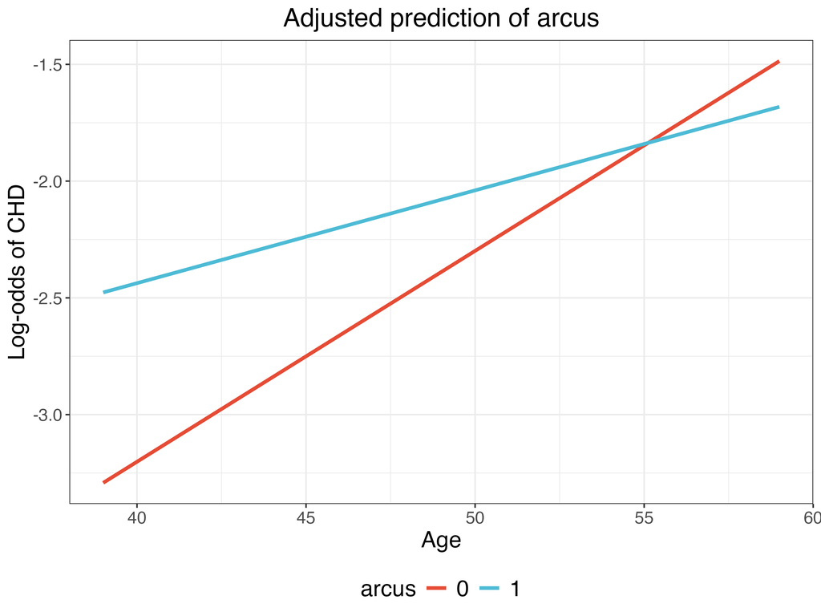

## Visualizing Interaction

**Y-axis = predicted probability of CHD**

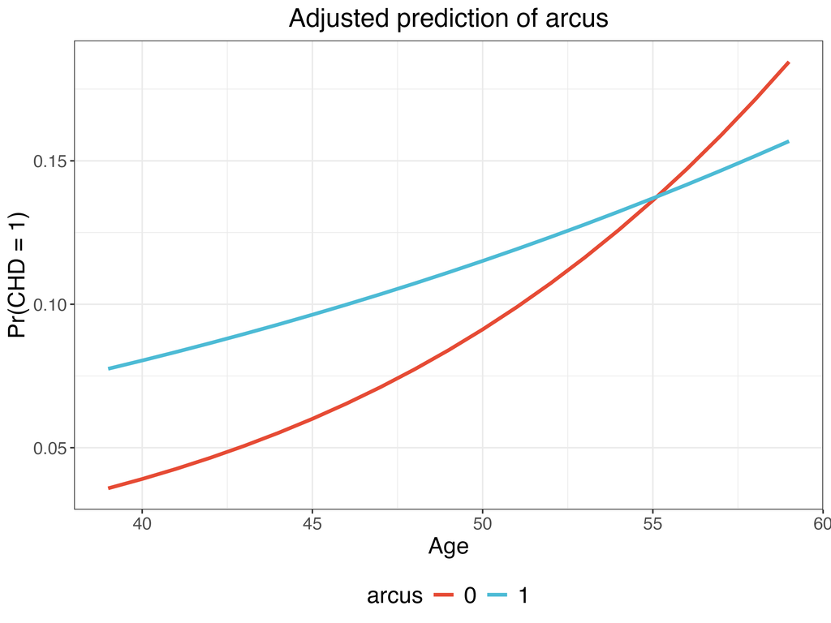

## Testing Interaction

$$g(\texttt{arcus},\texttt{age}) = \beta_0+\beta_1\texttt{arcus}+\beta_2\texttt{age}+ \textcolor{#9400D1}{\beta_3\texttt{age} \times \texttt{arcus}}$$

- To test for an interaction we test:
  - $H_0: \beta_3=0$
  - $H_1: \beta_3 \neq 0$

**Use LRT or Wald test**

## Testing $\beta_3$ with LRT

| Model | Log-likelihood |
| --- | --- |
| Full model: $\beta_0 + \beta_1\text{arcus} + \beta_2 \texttt{age} + \beta_3 \texttt{age} \times \texttt{arcus}$ | -857.7709 |
| Reduced model: $\beta_0 + \beta_1\text{arcus} + \beta_2 \texttt{age}$ | -860.1008 |

- Hypothesis: $H_0: \beta_3 = 0 \quad \text{vs.} \quad H_1: \beta_3 \neq 0$
- LRT test statistic: $G = 2\times(-857.7709 + 860.1008) = 4.66 > \chi_{1, 0.95}^2 = 3.84$
- $p$-value $= Pr(\chi_{1}^2 > G) = 0.03 < 0.05$ $\rightarrow$ Reject $H_0$
- Conclusion:
  - Odds ratio of CHD for arcus = 1 vs. arcus = 0 differs with age.
  - The effect of age on odds of CHD differs with arcus.

## Testing $\beta_3$ with Wald Test

| Covariate | Estimate of Coef. | Std. error |
| --- | --- | --- |
| `arcus` ($\beta_1$) | 2.787535 | 1.141064 |
| `age` ($\beta_2$) | 0.0903085 | 0.0149277 |
| `age` $\times$ `arcus` ($\beta_3$) | -0.0505671 | 0.0233638 |
| `Intercept` ($\beta_0$) | -6.814217 | 0.7197415 |

- Hypothesis: $H_0: \beta_3 = 0 \quad \text{vs.} \quad H_1: \beta_3 \neq 0$
- Wald test statistic: $Z = \dfrac{-0.0505671}{0.0233638} = -2.16$, $|Z| > z_{0.975} = 1.96$
- $p$-value $= 2 \times (1 - \Phi(|Z|)) = 0.03 < 0.05$ $\rightarrow$ Reject $H_0$
- Conclusion:
  - Odds ratio of CHD for arcus = 1 vs. arcus = 0 differs with age.
  - The effect of age on odds of CHD differs with arcus.